# BODY FAT

John Karuitha

2022-02-28

# **1 Introduction**

```r
BodyFat4 <- read_excel("BodyFat4.xlsx")
BodyFat4 <- BodyFat4 %>% set_names(names(.) %>% str_to_lower())
```

The dataset `Bodyfat4` shows the body fat percentage for 252 individuals. There are 13 variables. First, there is an identifier variable (IDNO) that uniquely identifies each observation. The body fat (BODYFAT) content is the dependent variable. The remaining eleven (11) are the independent variables that could explain the variability of body fat among the different individuals. The dataset has no missing values. The task is to build a regression model that can be useful in explaining and predicting the body fat of individuals. The data analysis proceeds as follows. In the next section, I visualize the data and then present summary statistics. Next, I present the correlation analysis and then the results of the regression.

# **2 Analysis and Interpretation of Results**

## **2.1 Descriptive Statistics**

Table () below shows a summary of the variables. Among the dependent variables, the highest variability(SD- standard deviation) is observed between individuals’ abdomen, age, and weight. For the dependent variable body fat, the mean is 18.9, with an unusual observation of zero body fat as the minimum value. Given that there is a base level of body fat necessary for humans to survive, this is a peculiar observation. For robustness, it would be advisable to drop this case.

```r
skim_without_charts(BodyFat4[,-1]) %>%
  dplyr::select(-c(skim_type, n_missing)) %>% tibble() %>%
  rename(Variable = skim_variable, Complete = complete_rate,
         Mean = numeric.mean, SD = numeric.sd, Min = numeric.p0,
         Q1 = numeric.p25, Median = numeric.p50, Q3 = numeric.p75,
         Max = numeric.p100) %>% knitr::kable()
```

| Variable | Complete | Mean | SD | Min | Q1 | Median | Q3 | Max |
| --- | --- | --- | --- | --- | --- | --- | --- | --- |
| bodyfat | 1 | 18.938492 | 7.7508557 | 0.000 | 12.8000 | 19.0000 | 24.6000 | 45.1000 |
| density | 1 | 1.055574 | 0.0190314 | 0.995 | 1.0414 | 1.0549 | 1.0704 | 1.1089 |
| age | 1 | 44.884921 | 12.6020397 | 22.000 | 35.7500 | 43.0000 | 54.0000 | 81.0000 |
| weight | 1 | 178.924405 | 29.3891599 | 118.500 | 159.0000 | 176.5000 | 197.0000 | 363.1500 |
| height | 1 | 70.148809 | 3.6628558 | 29.500 | 68.2500 | 70.0000 | 72.2500 | 77.7500 |
| adiposity | 1 | 25.436905 | 3.6481108 | 18.100 | 23.1000 | 25.0500 | 27.3250 | 48.9000 |
| thigh | 1 | 59.405952 | 5.2499520 | 47.200 | 56.0000 | 59.0000 | 62.3500 | 87.3000 |
| abdomen | 1 | 92.555952 | 10.7830768 | 69.400 | 84.5750 | 90.9500 | 99.3250 | 148.1000 |
| ankle | 1 | 23.102381 | 1.6948934 | 19.100 | 22.0000 | 22.8000 | 24.0000 | 33.9000 |
| hip | 1 | 99.904762 | 7.1640577 | 85.000 | 95.5000 | 99.3000 | 103.5250 | 147.7000 |
| wrist | 1 | 18.229762 | 0.9335849 | 15.800 | 17.6000 | 18.3000 | 18.8000 | 21.4000 |
| knee | 1 | 38.590476 | 2.4118046 | 33.000 | 36.9750 | 38.5000 | 39.9250 | 49.1000 |

## **2.2 Correlation Analysis**

In this section, I present the pairwise plots for all the variables, excluding the identifier variable (IDNO). The upper part of the figure shows the pairwise correlation between the variables. The main diagonal shows the distribution of the respective variable. For instance, the plot on the intersection of the first row and the first column shows the distribution of the body fat (BODYFAT) variable. The lower half shows the scatter plots for each pair of variables.

Figure 3.1:

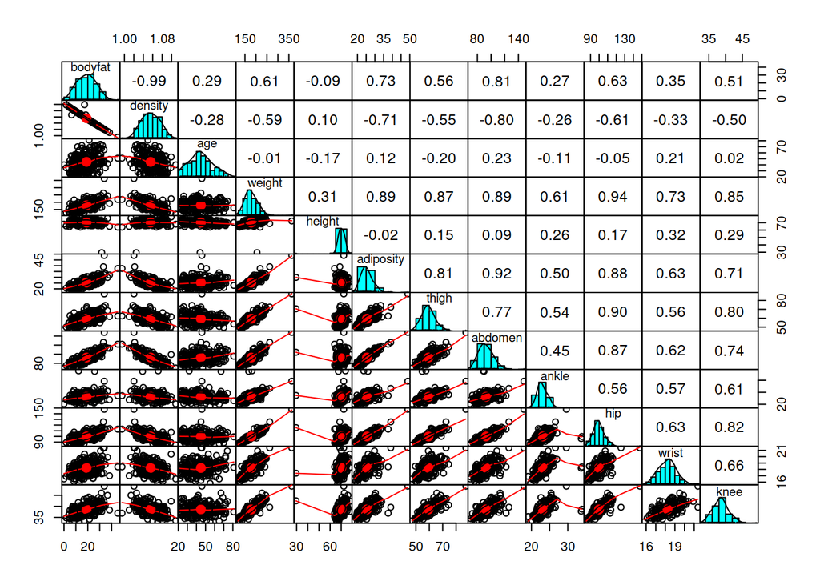

```r
BodyFat4[, 2:13] %>% pairs.panels(gap = 0, pch = 21, ssmooth = FALSE)
```

Figure () below is an extension of Figure () above and visualizes the correlation between the variables with the circle sizes showing the size of the correlation while the colour shows the direction (positive or negative).The red colouring corresponds to negative correlation while blue shows positive correlation. White is neutral indicating little correlation in either direction. It is important to note that in interpreting this visualization, I am Ignoring the main diagonal (which is the correlation of a variable with itself).

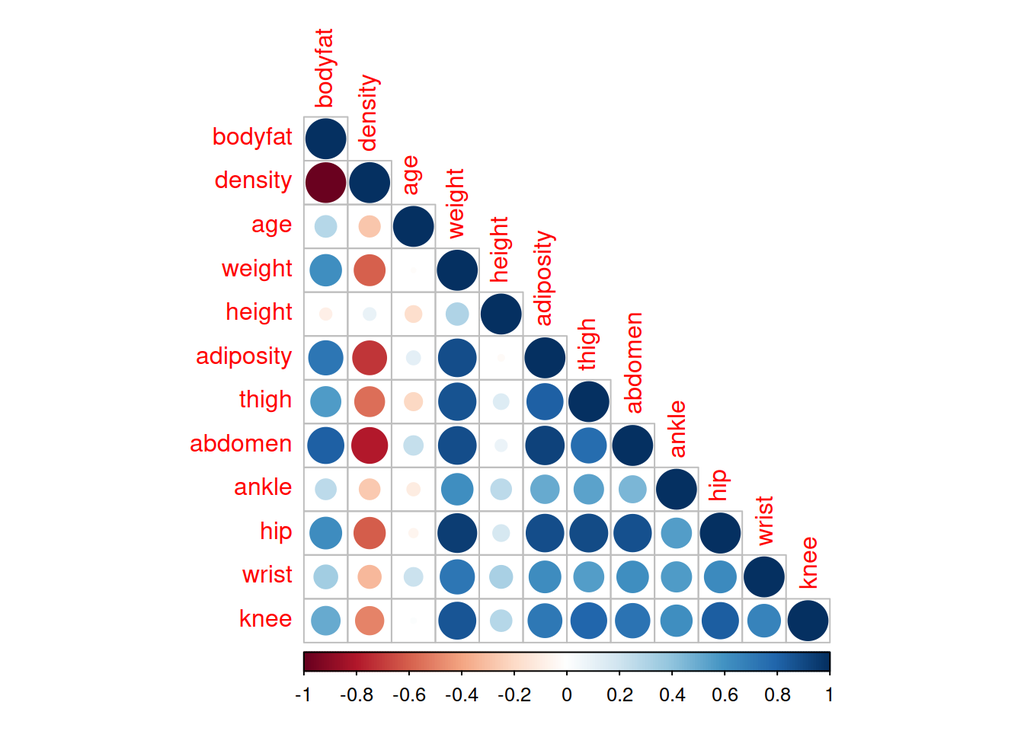

```r
corrplot(cor(BodyFat4[,-1]), type = "lower")
```

Multicollinearity is a problem because the independent variables in a regression model should ideally be independent. If not, the regression coefficient estimates become unstable (that is they vary a lot). The reduced precision of the estimates reduces the predictive power of the model (Frost 2019a). Scholars have suggested several solutions to the multicollinearity problem. The first is to drop the variables that exhibit multicollinearity. The second common technique is to use principal component analysis (PCA) to generate a new set of new variables (called components) that are linear combinations of the original variables but that have low correlation between them. In the next section, I describe and run the principal components analysis.

## **2.3 Principal Components Analysis (PCA)**

Principal components analysis (PCA) is a technique for dimension reduction, increasing interpretability while minimizing the loss of information (Jolliffe and Cadima 2016). PCA is especially useful where there are many variables in a dataset or as in this case where variables are highly correlated. The dimensions of the body fat dataset could be reduced to get rid of the highly correlated dependent variables by creating a new set of fewer variables called principle components that are not correlated. The principal components are linear combinations of the original variables that capture much of the variation in the original dataset. In this section, I construct principal components and discuss the applicability and limitations of the PCA analysis.

### **2.3.1 Running PCA**

PCA is sensitive to differences in scale between the variables used. Hence, it is recommended to first scale the variables (Zhu, Ge, and Song 2017). In this case, I scale the variables by subtracting the mean and dividing by the standard deviation.

```r
library(tidyverse)
pca <- BodyFat4[,3:13] %>% prcomp(scale. = TRUE, center = TRUE)
pca[1]
```

```
## $sdev
##  [1] 2.5769889 1.2466680 1.0195907 0.7856985 0.6512723 0.5231075 0.4405919
##  [8] 0.3389034 0.2627786 0.2057657 0.1728994
```

```r
pca[2] %>% knitr::kable()
```

|  | PC1 | PC2 | PC3 | PC4 | PC5 | PC6 | PC7 | PC8 | PC9 | PC10 | PC11 |
| --- | --- | --- | --- | --- | --- | --- | --- | --- | --- | --- | --- |
| density | -0.2680344 | 0.4082056 | -0.1055719 | -0.3038013 | 0.5643716 | -0.1637701 | 0.5083826 | -0.0536521 | 0.1067403 | -0.1882269 | 0.0677857 |
| age | 0.0237235 | -0.5610130 | -0.6643508 | -0.0569772 | 0.0024084 | -0.2972527 | 0.2584667 | 0.2769649 | -0.0138380 | 0.0721977 | -0.0530070 |
| weight | 0.3772631 | 0.0823905 | -0.0003205 | 0.0886518 | 0.1049909 | 0.0514025 | 0.2051173 | -0.1631618 | -0.0315995 | 0.0376282 | -0.8707758 |
| height | 0.0853037 | 0.5586899 | -0.4611461 | 0.5938833 | -0.2237492 | 0.0558422 | 0.1253866 | 0.0934278 | 0.1008100 | 0.0900581 | 0.1390328 |
| adiposity | 0.3577718 | -0.1841652 | 0.1293031 | -0.0331106 | 0.1083146 | 0.2605237 | 0.3115525 | -0.1569064 | 0.5688048 | 0.4744283 | 0.2652479 |
| thigh | 0.3461356 | 0.1012755 | 0.2906921 | 0.0387737 | 0.1639463 | -0.1722729 | -0.0688549 | 0.8095963 | 0.2008000 | -0.1636388 | -0.0092917 |
| abdomen | 0.3593055 | -0.2180146 | -0.0010456 | 0.1806343 | -0.0447768 | 0.1295240 | 0.2098289 | -0.2458256 | 0.0365149 | -0.7871370 | 0.2158277 |
| ankle | 0.2535765 | 0.2867944 | -0.1080678 | -0.6610140 | -0.6093952 | 0.0258560 | 0.1602675 | 0.0634257 | -0.0168730 | -0.0480934 | 0.0221932 |
| hip | 0.3683677 | 0.0255776 | 0.1521391 | 0.0651091 | 0.1484966 | -0.0724567 | 0.2782068 | 0.0060735 | -0.7592380 | 0.2708618 | 0.2858671 |
| wrist | 0.2903686 | 0.0983681 | -0.4420528 | -0.2572835 | 0.4238267 | 0.4564693 | -0.4922601 | 0.0220862 | -0.0903522 | -0.0254875 | 0.0692095 |
| knee | 0.3417161 | 0.1241960 | -0.0581284 | -0.0360538 | 0.0820601 | -0.7419231 | -0.3545537 | -0.3741894 | 0.1648345 | 0.0453712 | 0.1048233 |

Note that the PCA allows us to deal with the problem of correlation between variables. Table () below shows that the correlations between the principal components is now zero.

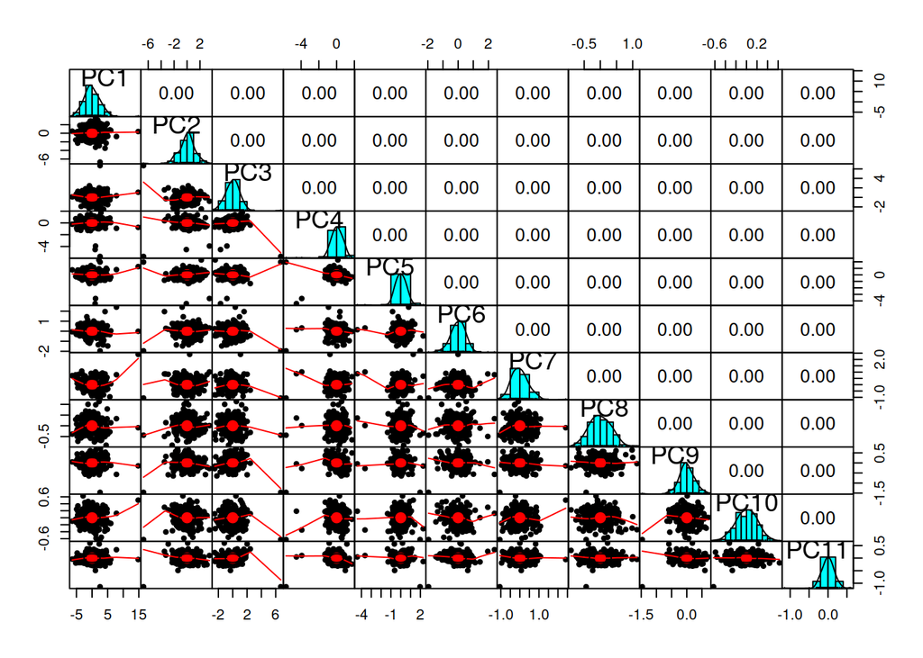

```r
pairs.panels(pca$x, gap = 0)
```

### **2.3.2 Composition of PCA**

The PCA output has two components

- Rotations

Table () shows the rotations where the original variables have reduced to the 11 principal components. As an example, principal component one (PC1) is formed by combining the respective variables using the weights given.

PC1 = -0.27 x density + 0.02 x age + ……….. + 0.34 x knee

Note that I have rounded the coefficients to 2 decimal places.

- Standard Deviations and importance of components

```r
summary(pca)
```

```
## Importance of components:
##                           PC1    PC2     PC3     PC4     PC5     PC6     PC7
## Standard deviation     2.5770 1.2467 1.01959 0.78570 0.65127 0.52311 0.44059
## Proportion of Variance 0.6037 0.1413 0.09451 0.05612 0.03856 0.02488 0.01765
## Cumulative Proportion  0.6037 0.7450 0.83951 0.89563 0.93419 0.95907 0.97671
##                            PC8     PC9    PC10    PC11
## Standard deviation     0.33890 0.26278 0.20577 0.17290
## Proportion of Variance 0.01044 0.00628 0.00385 0.00272
## Cumulative Proportion  0.98716 0.99343 0.99728 1.00000
```

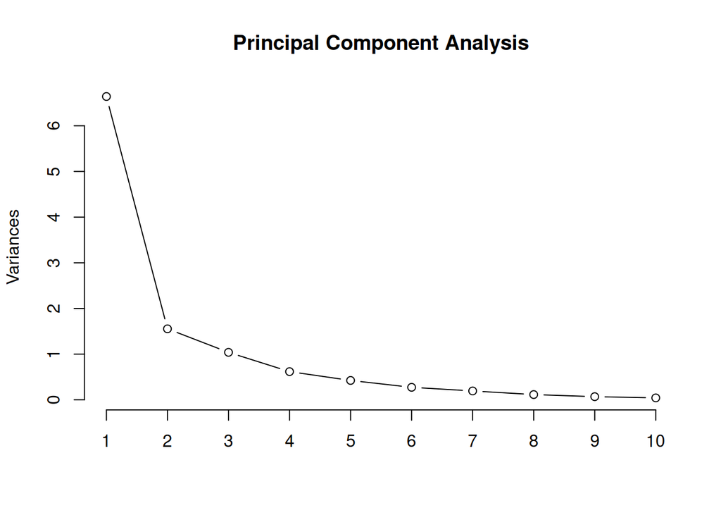

```r
plot(pca, type = "l", main = "Principal Component Analysis")
```

### **2.3.3 Exploring the Principal Components**

- Low: 0 to 10 inclusive
- Medium: Greater than 10 but less than or equal to 20.
- High Greater than 20 but less than or equal to 30.
- Very high: Greater than 30.

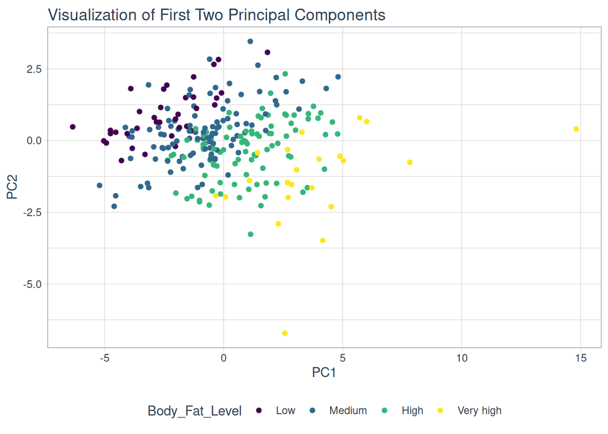

```r
BodyFat4 <- BodyFat4 %>% bind_cols(pca$x %>% data.frame())
BodyFat4 <- BodyFat4 %>% mutate(Body_Fat_Level = case_when(
  bodyfat >= 0 & bodyfat <= 10 ~ "Low",
  bodyfat > 10 & bodyfat <= 20 ~ "Medium",
  bodyfat > 20 & bodyfat <= 30 ~ "High",
  TRUE ~ "Very high"
))

BodyFat4$Body_Fat_Level <- factor(BodyFat4$Body_Fat_Level, ordered = TRUE, levels = c("Low", "Medium", "High", "Very high"))

BodyFat4 %>% ggplot(aes(x = PC1, y = PC2, col = Body_Fat_Level)) + geom_point() +
  labs(title = "Visualization of First Two Principal Components") +
  theme(legend.title = element_text("Body Fat")) + tidyquant::theme_tq()
```

I also visualize each of the principal components faceted by the `Body_Fat_Level` defined above.

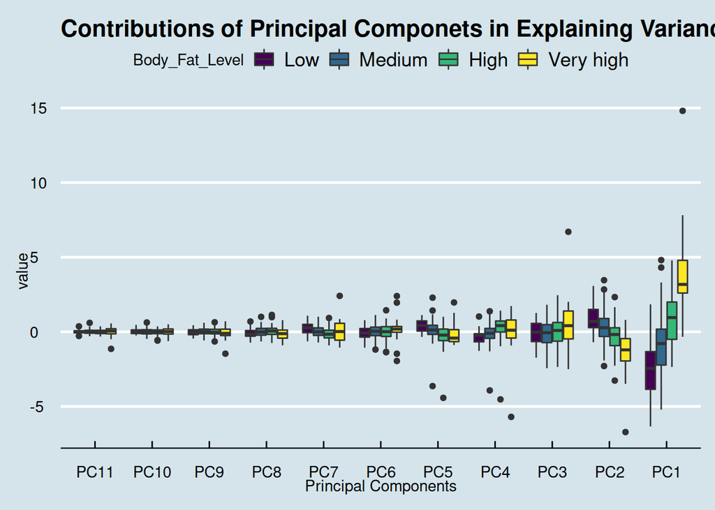

```r
BodyFat4 %>% .[,-c(1:13)] %>% pivot_longer(cols = starts_with("PC"), names_to = "prcomp", values_to = "value") %>% ggplot(aes(x = reorder(prcomp, value, sd), y = value, fill = Body_Fat_Level)) + geom_boxplot() + labs(x = "Principal Components", title = "Contributions of Principal Componets in Explaining Variance") +
  ggthemes::theme_economist()
```

lastly, we examine the correlation between PC1, PC2 and PC3 and the variables of BodyFat dataset. Table () shows that PC1 has very high correlation with most of the variables. For instance, PC1 has a correlation greater than 0.7 (absolute value) with 7 of the 11 independent variables. PC2 is not so strong but still has a correlation above 0.6 (absolute) with 2 variables, while PC3 has a correlation greater than 0.6 with one variable. In this case, it appears like PC1 and PC2 are adequate to capture most of the variability in the data.

|  | PC1 | PC2 | PC3 |
| --- | --- | --- | --- |
| density | -0.6907217 | 0.5088969 | -0.1076402 |
| age | 0.0611353 | -0.6993969 | -0.6773658 |
| weight | 0.9722029 | 0.1027136 | -0.0003268 |
| height | 0.2198266 | 0.6965008 | -0.4701802 |
| adiposity | 0.9219741 | -0.2295929 | 0.1318363 |
| thigh | 0.8919875 | 0.1262570 | 0.2963869 |
| abdomen | 0.9259263 | -0.2717918 | -0.0010661 |
| ankle | 0.6534638 | 0.3575373 | -0.1101849 |
| hip | 0.9492794 | 0.0318868 | 0.1551197 |
| wrist | 0.7482767 | 0.1226324 | -0.4507129 |
| knee | 0.8805986 | 0.1548312 | -0.0592672 |

## **2.4 Regression Analysis**

In this section, I start by doing a forward stepwise regression followed by the required backward stepwise regression. Forward stepwise regression starts with no independent variables in the model and iteratively adds predictors that are the most significant. The process stops when the improvement is no longer statistically significant. On the contrary, the backward stepwise regression starts with all the independent variables in the model and removes the least contributing variables until all variables remaining are significant [Bruce, Bruce, and Gedeck (2020)](James et al. 2013).

### **2.4.1 Forward Stepwise Regression**

I include the forward stepwise selection method for purposes of comparison. Note that the optimal model here includes all variables, although only the density is significant. Overall, the model captures 97.74% of the variation in body fat (see adjusted R squared in the table below).

```r
# Fit full model
forward.full.model <- lm(bodyfat ~ density + age + weight + height + adiposity +
                           thigh + abdomen + ankle + hip + wrist + knee,
                           data = BodyFat4)

# Do forward selection
forward.step.model <- step(forward.full.model, direction = "forward",
                      trace = TRUE)
```

```
## Start:  AIC=88.26
## bodyfat ~ density + age + weight + height + adiposity + thigh +
##     abdomen + ankle + hip + wrist + knee
```

```r
summary(forward.step.model)
```

```
##
## Call:
## lm(formula = bodyfat ~ density + age + weight + height + adiposity +
##     thigh + abdomen + ankle + hip + wrist + knee, data = BodyFat4)
##
## Residuals:
##     Min      1Q  Median      3Q     Max
## -7.7873 -0.3008 -0.0746  0.1748 14.2447
##
## Coefficients:
##               Estimate Std. Error t value Pr(>|t|)
## (Intercept)  4.202e+02  9.315e+00  45.107   <2e-16 ***
## density     -3.814e+02  7.365e+00 -51.782   <2e-16 ***
## age          9.340e-03  8.623e-03   1.083    0.280
## weight       1.324e-02  1.273e-02   1.040    0.299
## height      -1.936e-02  3.009e-02  -0.643    0.521
## adiposity   -4.078e-02  7.374e-02  -0.553    0.581
## thigh       -1.931e-02  3.763e-02  -0.513    0.608
## abdomen      3.499e-02  2.820e-02   1.240    0.216
## ankle       -7.042e-02  5.979e-02  -1.178    0.240
## hip          1.182e-02  3.745e-02   0.315    0.753
## wrist        2.449e-02  1.373e-01   0.178    0.859
## knee        -3.059e-02  6.630e-02  -0.461    0.645
## ---
## Signif. codes:  0 '***' 0.001 '**' 0.01 '*' 0.05 '.' 0.1 ' ' 1
##
## Residual standard error: 1.164 on 240 degrees of freedom
## Multiple R-squared:  0.9784, Adjusted R-squared:  0.9774
## F-statistic: 989.9 on 11 and 240 DF,  p-value: < 2.2e-16
```

### **2.4.2 Backward Stepwise Regression**

The AIC captures the extent to which the model fits the data without being overly complex. Complexity refers to the number of parameters in the model and fittingly, AIC is the difference between the number of parameters in the model (k) and the maximum value of the likelihood function of the model (L).

AIC = (2 * k ) - (2 * ln(L)), where ln stands for natural log.

The central idea of AIC is to balance between fitting the data and the need not to overfit the dataset (Portet 2020).

The model is captured at the bottom of the series of tables. In the model, only age is not significant at 10% significance level. As expected, the model explains 97.79% of the variation in body fat - the adjusted R-Squared - which is a high level of in sample sensitivity. The adjusted R-Squared derives from the R-squared, a goodness-of-fit measure for linear regression models that indicates the percentage of the variance in the dependent variable that the independent variables explain collectively (Frost 2019b). Like the AIC, the adjusted R-squared penalizes the R-squared as the model gets more complex, that is, gets more predictors.

Furthermore the model as a whole is highly significant going by the F-test . The F-test of overall significance tests how well the linear regression model better fits the data compared to a model that has no independent variables or in other words where the coefficients of the independent variables are all zero. In out case the F-test is highly significant meaning that the model better explains the model better than a model with no predictors. If our model fits the data just as well as a model with no predictors, then the F_statistic should be close to one. In this case it is 3703.

```r
# Fit full model
backward.full.model <- lm(bodyfat ~ density + age + weight + height + adiposity +
                           thigh + abdomen + ankle + hip + wrist + knee,
                           data = BodyFat4)

# Do forward selection
backward.step.model <- step(backward.full.model, direction = "backward",
                      trace = TRUE)
```

```
## Start:  AIC=88.26
## bodyfat ~ density + age + weight + height + adiposity + thigh +
##     abdomen + ankle + hip + wrist + knee
##
##             Df Sum of Sq    RSS    AIC
## - wrist      1       0.0  325.2  86.29
## - hip        1       0.1  325.3  86.36
## - knee       1       0.3  325.5  86.48
## - thigh      1       0.4  325.5  86.53
## - adiposity  1       0.4  325.6  86.58
## - height     1       0.6  325.8  86.69
## - weight     1       1.5  326.7  87.39
## - age        1       1.6  326.8  87.49
## - ankle      1       1.9  327.1  87.71
## - abdomen    1       2.1  327.3  87.87
## <none>                    325.2  88.26
## - density    1    3633.1 3958.3 716.04
##
## Step:  AIC=86.29
## bodyfat ~ density + age + weight + height + adiposity + thigh +
##     abdomen + ankle + hip + knee
##
##             Df Sum of Sq    RSS    AIC
## - hip        1       0.1  325.4  84.38
## - knee       1       0.3  325.5  84.50
## - thigh      1       0.4  325.6  84.56
## - adiposity  1       0.4  325.6  84.59
## - height     1       0.5  325.8  84.70
## - weight     1       1.7  327.0  85.63
## - ankle      1       1.8  327.1  85.72
## - abdomen    1       2.1  327.3  85.88
## - age        1       2.1  327.3  85.90
## <none>                    325.2  86.29
## - density    1    3792.0 4117.3 723.97
##
## Step:  AIC=84.38
## bodyfat ~ density + age + weight + height + adiposity + thigh +
##     abdomen + ankle + knee
##
##             Df Sum of Sq    RSS    AIC
```

[output cut: 66 more lines]

```
##           Df Sum of Sq    RSS    AIC
## - ankle    1       1.4  329.3  75.39
## - age      1       2.3  330.1  76.06
## <none>                  327.8  76.29
## - abdomen  1      24.7  352.5  92.57
## - density  1    4475.0 4802.9 750.78
##
## Step:  AIC=75.39
## bodyfat ~ density + age + abdomen
##
##           Df Sum of Sq    RSS    AIC
## <none>                  329.3  75.39
## - age      1       3.3  332.6  75.92
## - abdomen  1      24.3  353.5  91.32
## - density  1    4601.0 4930.3 755.38
```

```r
summary(backward.step.model)
```

```
##
## Call:
## lm(formula = bodyfat ~ density + age + abdomen, data = BodyFat4)
##
## Residuals:
##     Min      1Q  Median      3Q     Max
## -7.7157 -0.3081 -0.0784  0.2066 14.4599
##
## Coefficients:
##               Estimate Std. Error t value Pr(>|t|)
## (Intercept)  4.141e+02  7.681e+00  53.910  < 2e-16 ***
## density     -3.790e+02  6.437e+00 -58.869  < 2e-16 ***
## age          9.510e-03  6.008e-03   1.583    0.115
## abdomen      4.797e-02  1.122e-02   4.277 2.71e-05 ***
## ---
## Signif. codes:  0 '***' 0.001 '**' 0.01 '*' 0.05 '.' 0.1 ' ' 1
##
## Residual standard error: 1.152 on 248 degrees of freedom
## Multiple R-squared:  0.9782, Adjusted R-squared:  0.9779
## F-statistic:  3703 on 3 and 248 DF,  p-value: < 2.2e-16
```

### **2.4.3 Checking the Regression Assumptions**

```r
cor(BodyFat4[,3], BodyFat4[,c(4, 9)]) %>% knitr::kable()
```

|  | age | abdomen |
| --- | --- | --- |
| density | -0.2776372 | -0.7989546 |

```r
lm(bodyfat ~ density + age, data = BodyFat4) %>% summary()
```

```
##
## Call:
## lm(formula = bodyfat ~ density + age, data = BodyFat4)
##
## Residuals:
##     Min      1Q  Median      3Q     Max
## -8.1033 -0.2150 -0.0945  0.0513 15.7176
##
## Coefficients:
##               Estimate Std. Error t value Pr(>|t|)
## (Intercept)  4.414e+02  4.428e+00  99.663   <2e-16 ***
## density     -4.006e+02  4.114e+00 -97.381   <2e-16 ***
## age          9.892e-03  6.212e-03   1.592    0.113
## ---
## Signif. codes:  0 '***' 0.001 '**' 0.01 '*' 0.05 '.' 0.1 ' ' 1
##
## Residual standard error: 1.192 on 249 degrees of freedom
## Multiple R-squared:  0.9766, Adjusted R-squared:  0.9764
## F-statistic:  5186 on 2 and 249 DF,  p-value: < 2.2e-16
```

Note that this simplified model consisting of density and age (to the exclusion of abdomen) captures most of the information. The adjusted R-squared is 97.64% compared to 97.79% of the previous model that included abdomen. Age remains insignificant in both cases (10% significant level).

Another important issue arising here is that of some influential observations (outliers) the graph titled residuals versus leverage shows. In this case, there is an influential observation that may affect our inferences.

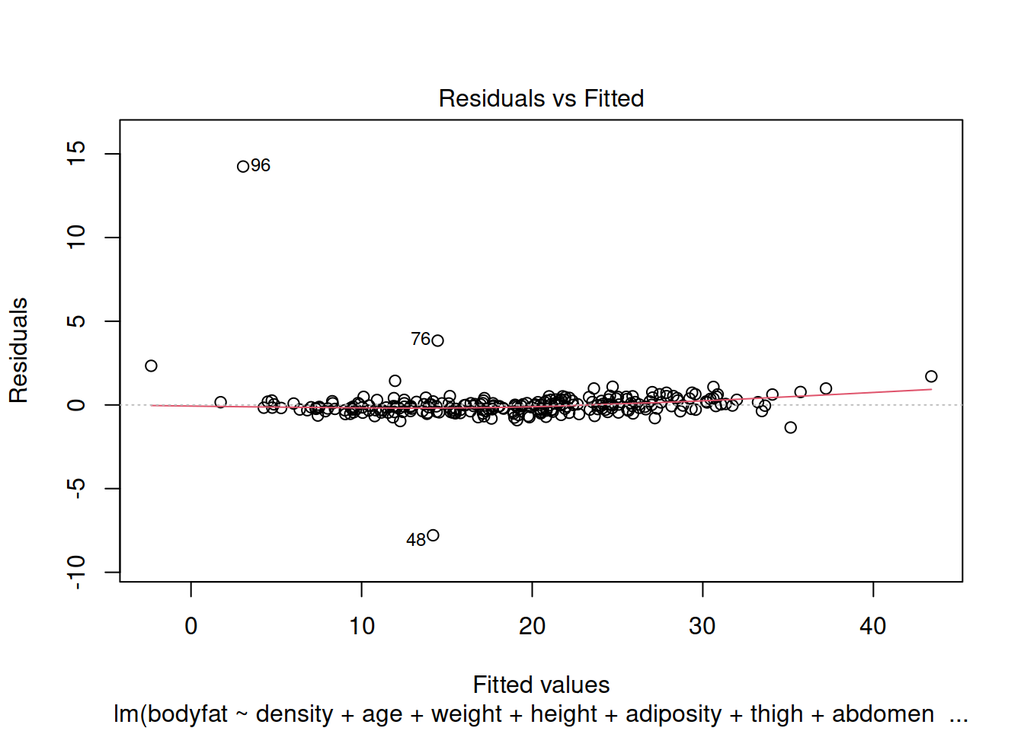

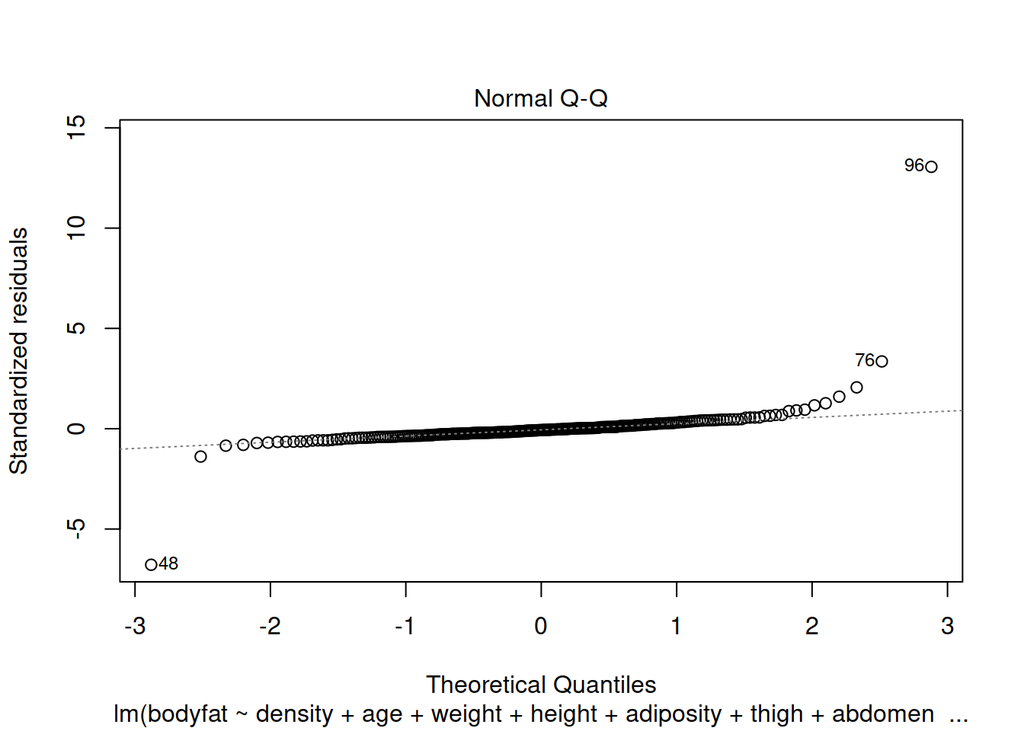

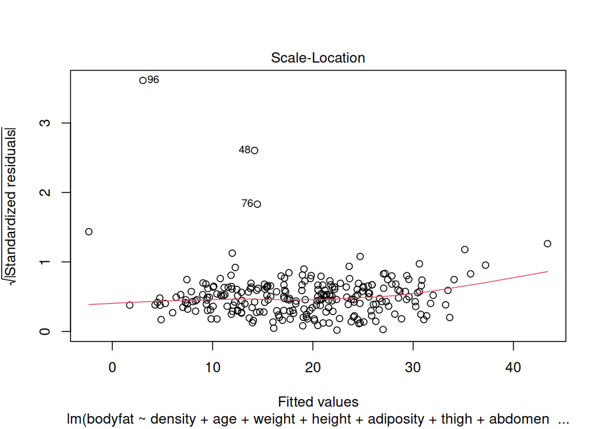

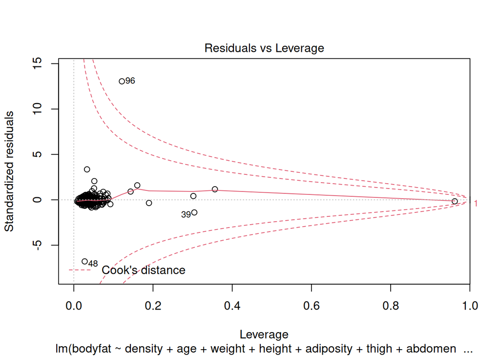

```r
plot(backward.full.model)
```